# Hw08 - Geostatistics Homework (Prediction)

The `cow.rda` file contains a data frame with 200 spatial observations observed throughout the state of Colorado. The data frame includes `easting` and `northing` coordinates (UTM, scaled by 1000 meters) and Tungsten measurements (`W`) at each site (mg/kg). Read in the data as a data frame from the file.

# Preliminaries

Load the **gstat** and **geoR** packages. Load the `cow.rda` file.

```r
load("cow.rda")
```

```r
library(ggplot2)
library(gstat)
library(geoR)
```

# Problem 0

Create `cow_sf`, an `sf` version of `cow` that uses `easting` and `northing` for `coords`.

Create `geocow`, a `geodata` object from the **geoR** package.

Also run the following code.

```r
set.seed(1)

poly_sf <- sf::st_polygon(x = list(cbind(
  c(152, 152, 753, 753, 152),
  c(4100, 4544, 4544, 4100, 4100))))



grid_sf <- sf::st_sample(poly_sf, size = 100,
                         type = "regular")

cow_sf <- sf::st_as_sf(cow,
                       coords = c("easting", "northing"))

geocow = as.geodata(cbind(cow$easting , cow$northing,cow$W))
```

**Solution**

# Problem 1 (Using geoR)

Use REML estimation with a constant mean function to fit the following covariance models to the data:

1. An isotropic spherical model.
2. A geometric anisotropic spherical model.
3. An isotropic exponential model.
4. A geometric anisotropic exponential model.

Make a table that provides the following information about each model: model, partial sill ($c$), range parameter ($a$ or $a_{min}$), nugget ($c_0$), direction of the major axis in degrees, (if appropriate), anisotropy ratio $a_{max}/a_{min}$, AIC of the fit.

Note: starting values make a HUGE difference for the anisotropic models, so you probably want to experiment a bit.

Which model is the best choice?

```r
variog1b = variog(geocow)
```

```
variog: computing omnidirectional variogram
```

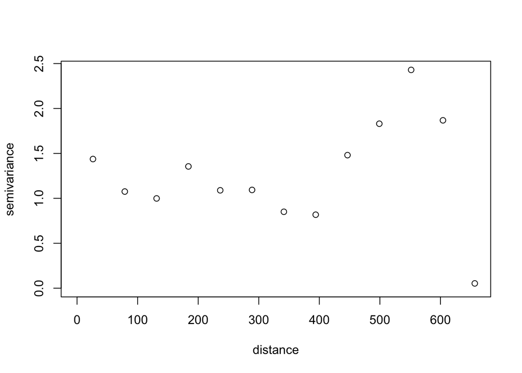

```r
plot(variog1b)
```

```r
###Isotropic Spherical
lfit_sph = likfit(geocow,
                  ini.cov.pars = c(1.5, 500),
                  nugget = 0.5,
                  cov.model = "spherical",
                  lik.method = "REML",
                  trend = "cte")
```

[output not shown]

```r
lfit_sph
```

```
likfit: estimated model parameters:
      beta      tausq    sigmasq        phi
"  0.8691" "  1.1267" "  0.0613" "628.1276"
Practical Range with cor=0.05 for asymptotic range: 628.1276

likfit: maximised log-likelihood = -296.6
```

```r
v <- variog4(geocow)
```

```
variog: computing variogram for direction = 0 degrees (0 radians)
        tolerance angle = 22.5 degrees (0.393 radians)
variog: computing variogram for direction = 45 degrees (0.785 radians)
        tolerance angle = 22.5 degrees (0.393 radians)
variog: computing variogram for direction = 90 degrees (1.571 radians)
        tolerance angle = 22.5 degrees (0.393 radians)
variog: computing variogram for direction = 135 degrees (2.356 radians)
        tolerance angle = 22.5 degrees (0.393 radians)
variog: computing omnidirectional variogram
```

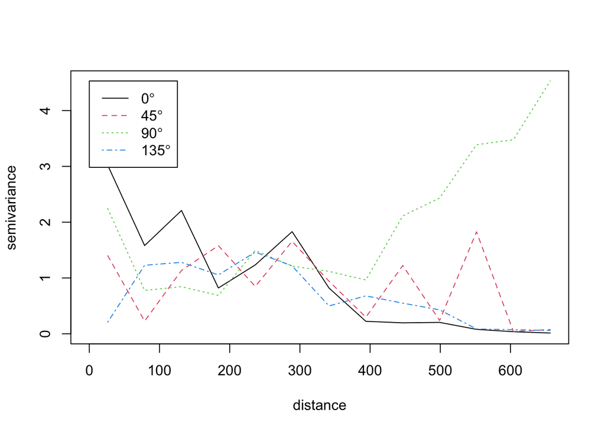

```r
plot(v)
```

```r
amax <- 600
amin <- 300
a <- 600/300


###Anisorpic Spherical
lfit1 = likfit(geocow, ini.cov.pars = c(1.5, 500),
               nugget = 0.5,
               cov.model = "spherical",
               lik.method = "REML",
               psiA = 70/180*pi,
               psiR = a,
               trend = "cte")
```

[output not shown]

```r
####Isotropic Exp
lfit_exp = likfit(geocow,
                  ini.cov.pars = c(1.5, 500),
                  nugget = 0.5,
                  cov.model = "exponential",
                  lik.method = "REML",
                  trend = "cte")
```

[output not shown]

```r
###Anisorpic Exp
lfit2 = likfit(geocow, ini.cov.pars = c(1.5, 500),
               nugget = 0.5,
               cov.model = "exponential",
               lik.method = "REML",
               psiA = 70/180*pi,
               psiR = a,
               trend = "cte")
```

[output not shown]

```r
model <- c("Isotropic Spherical", "Anisorpic Spherical", "Isotropic Exp", "Anisorpic Exp")
```

```r
# Parameters from your model fits
partial_sill <- c(lfit_sph$sigmasq,  lfit1$sigmasq, lfit_exp$sigmasq,lfit2$sigmasq)

range_param   <- c(lfit_sph$phi, lfit1$phi, lfit_exp$phi,lfit2$phi)

nugget        <- c(lfit_sph$nugget, lfit1$nugget, lfit_exp$nugget, lfit2$nugget)

direction_deg <- c(lfit_sph$aniso.pars[1],lfit1$aniso.pars[1], lfit_exp$aniso.pars[1], lfit2$aniso.pars[1])

psiR <- c(lfit_sph$aniso.pars[2],lfit1$aniso.pars[2], lfit_exp$aniso.pars[2], lfit2$aniso.pars[2])

AIC  <- c(lfit_sph$AIC, lfit1$AIC, lfit_exp$AIC, lfit2$AIC)

model_summary <- data.frame(
  Model = model,
  Partial_Sill = partial_sill,
  Range = range_param,
  Nugget = nugget,
  Direction_Degrees = direction_deg,
  Anisotropy_Ratio = psiR,
  AIC = AIC
)

model_summary
```

```
                Model Partial_Sill    Range   Nugget Direction_Degrees
1 Isotropic Spherical   0.06130883 628.1276 1.126667           0.00000
2 Anisorpic Spherical   0.06382129 315.0021 1.114505           1.22173
3       Isotropic Exp   0.09262560 500.2208 1.124876           0.00000
4       Anisorpic Exp   0.15289973 500.0473 1.117254           1.22173
  Anisotropy_Ratio      AIC
1                1 601.1442
2                2 600.4996
3                1 601.1641
4                2 600.8860
```

```r
model_summary$Model[which.min(AIC)]
```

```
[1] "Anisorpic Spherical"
```

**Solution** The best model using only AIC would be Anisorpic Spherical which makes sense because if we do look at our variogram when split into 4 different groups we see that not all of them follow the same trend on distance. Thus, of course if we acount for this in our anisopric model it is going to preform better even though we might be estimating more parameters.

# Problem 2

Create two `gstat` objects with a constant mean and the directional semivariogram model that matches the REML fit provided below. For the first, assume the nugget is microscale error (standard kriging) while the second is measurement error (filtered kriging).

Reminder: **gstat** and **geoR** parameterize the angle and ratio of the $a_{minor}$ and $a_{major}$ differently, so carefully read the documentation.

```
Summary of the parameter estimation
-----------------------------------
Estimation method: restricted maximum likelihood

Parameters of the mean component (trend):
  beta
0.9343

Parameters of the spatial component:
   correlation function: exponential
      (estimated) variance parameter sigmasq (partial sill) =  1.158
      (estimated) cor. fct. parameter phi (range parameter)  =  3.276
   anisotropy parameters:
      (fixed) anisotropy angle = 0.7854  ( 45.0001052295748 degrees )
      (fixed) anisotropy ratio = 2

Parameter of the error component:
      (estimated) nugget =  0.102

Transformation parameter:
      (fixed) Box-Cox parameter = 1 (no transformation)

Practical Range with cor=0.05 for asymptotic range: 9.812505

Maximised Likelihood:
   log.L n.params      AIC      BIC
"-296.1"      "4"  "600.1"  "613.3"

non spatial model:
   log.L n.params      AIC      BIC
"-297.6"      "2"  "599.1"  "605.7"

Call:
likfit(geodata = geocow, ini.cov.pars = c(0.5, 10), fix.nugget = FALSE,
    nugget = 0.1, fix.psiA = TRUE, psiA = pi/4, fix.psiR = TRUE,
    psiR = 2, cov.model = "exponential", lik.method = "REML",
    messages = FALSE)
```

**Solution**

```r
# vgm(c, "model", amax = amin * psiR, c0),
#     anis = c(angle, 1/psiR = amin/amax)

fitkrig =  vgm(psill = 1.158,
            model = "Exp",
            range = 3.2760,
            nugget = .102,
            anis = c(45.0001052295748, 1/2))

ganiso1 = gstat(id = "k", formula = W ~ 1, data = cow_sf,
                model = fitkrig)

fitnoiseykrigy  = vgm(psill = 1.158,
            model = "Exp",
            range = 3.2760,
            anis = c(45.0001052295748, 1/2),
            Err = .102)

ganiso2 = gstat(id = "k", formula = W ~ 1, data = cow_sf,
                model = fitnoiseykrigy)
```

# Problem 3

Perform standard kriging at the locations contained in `grid_sf` using the `gstat` object created in the previous problem.

Use the `summary` function to summarize your results.

**Solution**

```r
ok = predict(ganiso1, data = cow_sf, newdata = grid_sf)
```

```
[using ordinary kriging]
```

```r
summary(ok)
```

```
     k.pred           k.var          geometry
 Min.   :0.8622   Min.   :1.025   POINT  :108
 1st Qu.:0.9423   1st Qu.:1.266   epsg:NA:  0
 Median :0.9426   Median :1.266
 Mean   :0.9432   Mean   :1.261
 3rd Qu.:0.9427   3rd Qu.:1.266
 Max.   :1.2852   Max.   :1.266
```

# Problem 4

Perform filtered kriging at the locations contained in `grid_sf` using the `gstat` object created in Problem 2.

Use the `summary` function to summarize your results.

**Solution**

```r
noisek = predict(ganiso2, data = cow_sf, newdata = grid_sf)
```

```
[using ordinary kriging]
```

```r
summary(noisek)
```

```
     k.pred           k.var           geometry
 Min.   :0.8622   Min.   :0.9231   POINT  :108
 1st Qu.:0.9423   1st Qu.:1.1643   epsg:NA:  0
 Median :0.9426   Median :1.1644
 Mean   :0.9432   Mean   :1.1590
 3rd Qu.:0.9427   3rd Qu.:1.1644
 Max.   :1.2852   Max.   :1.1644
```

# Problem 5

Are the predictions for standard and filtered kriging identical for the predictions above? Why?

**Solution**

Create side-by-side plots of the kriging variances from Problems 3 and 4 with a common color scale. Which variances are higher?

**Solution**

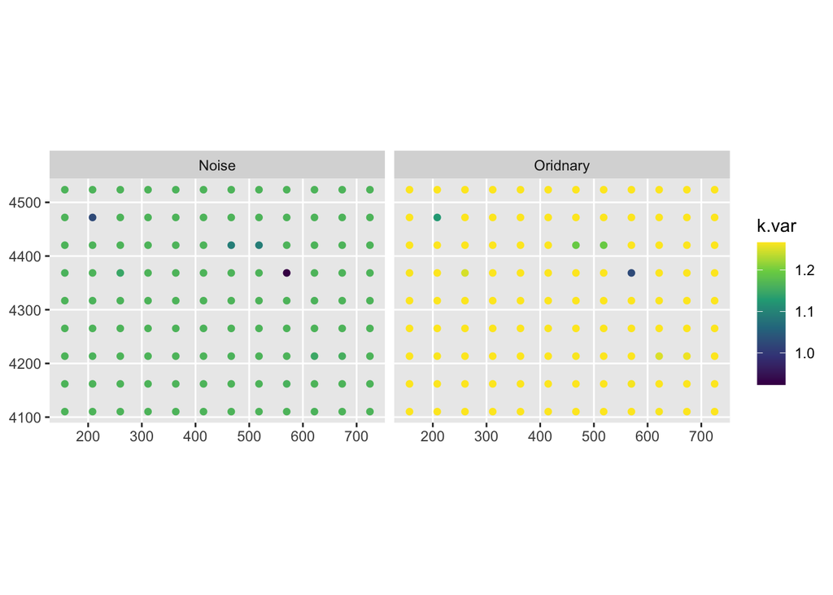

```r
predictions_bloack <- rbind(
  cbind(ok[c("k.pred", "k.var")], type = "Oridnary"),
  cbind(noisek[c("k.pred", "k.var")], type = "Noise"))

# plot of kriging variance
ggplot(predictions_bloack) +
  geom_sf(aes(fill = k.var, color = k.var)) +
  facet_wrap(~ type) +
  scale_fill_viridis_c() +
  scale_color_viridis_c()
```

# Problem 7

Perform standard kriging at the locations contained in `cow_sf` using the `gstat` object created in Problem 2.

Use the `summary` function to summarize your results.

Perform filtered kriging at the locations contained in `grid_sf` using the `gstat` object created in Problem 2.

Use the `summary` function to summarize your results.

**Solution**

```r
ok2 = predict(ganiso1, data = cow_sf, newdata = cow_sf)
```

```
[using ordinary kriging]
```

```r
summary(ok2)
```

```
     k.pred           k.var               geometry
 Min.   : 0.200   Min.   :-6.661e-16   POINT  :200
 1st Qu.: 0.600   1st Qu.:-5.551e-17   epsg:NA:  0
 Median : 0.800   Median : 0.000e+00
 Mean   : 0.947   Mean   :-1.665e-17
 3rd Qu.: 1.000   3rd Qu.: 0.000e+00
 Max.   :14.000   Max.   : 6.661e-16
```

# Problem 8

Perform filtered kriging at the locations contained in `cow_sf` using the `gstat` object created in Problem 2.

Use the `summary` function to summarize your results.

**Solution**

```r
noisek2 = predict(ganiso2, data = cow_sf, newdata = cow_sf)
```

```
[using ordinary kriging]
```

```r
summary(noisek2)
```

```
     k.pred            k.var            geometry
 Min.   : 0.2594   Min.   :0.09281   POINT  :200
 1st Qu.: 0.6277   1st Qu.:0.09378   epsg:NA:  0
 Median : 0.8115   Median :0.09378
 Mean   : 0.9470   Mean   :0.09377
 3rd Qu.: 0.9954   3rd Qu.:0.09378
 Max.   :12.9430   Max.   :0.09378
```

# Problem 9

Are the standard and unfiltered kriging predictions the same at the observed data locations? Why?

**Solution**

# Problem 10

What do you notice about the kriging variances for the filtered and unfilted kriging predictions at observed data locations?

**Solution**

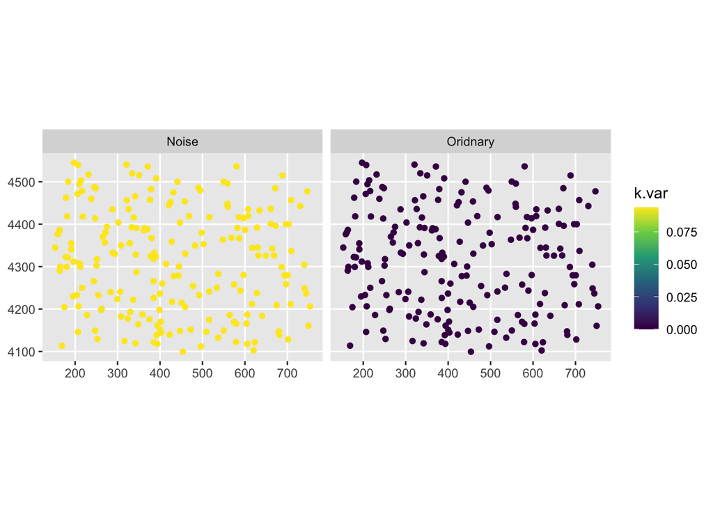

```r
predictions_bloack <- rbind(
  cbind(ok2[c("k.pred", "k.var")], type = "Oridnary"),
  cbind(noisek2[c("k.pred", "k.var")], type = "Noise"))

# plot of kriging variance
ggplot(predictions_bloack) +
  geom_sf(aes(fill = k.var, color = k.var)) +
  facet_wrap(~ type) +
  scale_fill_viridis_c() +
  scale_color_viridis_c()
```

This question builds off very similar to the last. WIth ordinary we make sure that we go trhough our data, hwoever, with filtered kriging we are instead assuming that our data is noisy thus we don’t have to 100 percent go trhough it and we can have some variation within it.